# Simon Rodriguez

Practical Machine Learning - Final project

13th of September, 2017

# Introduction

Using devices such as Jawbone Up, Nike FuelBand, and Fitbit it is now possible to collect a large amount of data about personal activity relatively inexpensively. These type of devices are part of the quantified self movement - a group of enthusiasts who take measurements about themselves regularly to improve their health, to find patterns in their behavior, or because they are tech geeks. One thing that people regularly do is quantify how much of a particular activity they do, but they rarely quantify how well they do it. In this project, our goal will be to use data from accelerometers on the belt, forearm, arm, and dumbell of 6 participants. They were asked to perform barbell lifts correctly and incorrectly in 5 different ways. More information is available from the website here: http://groupware.les.inf.puc-rio.br/har (see the section on the Weight Lifting Exercise Dataset).

### Data

The training data for this project are available here: https://d396qusza40orc.cloudfront.net/predmachlearn/pml-training.csv

The test data are available here: https://d396qusza40orc.cloudfront.net/predmachlearn/pml-testing.csv

The data for this project come from this source: http://groupware.les.inf.puc-rio.br/har.

# Preparation and setting

First of all, we begin loading the neccessary packages

```r
library(caret)
library(ggplot2)
library(reshape2)
library(rpart)
library(rpart.plot)
library(rattle)
library(randomForest)
library(reprtree)
```

Now, import the data from the URL’s and load them from the local directory

```r
# Download the files in case they are not available in the working directory
if (!file.exists("trainPML.csv")){
      trainURL <- "https://d396qusza40orc.cloudfront.net/predmachlearn/pml-training.csv"
      testURL <- "https://d396qusza40orc.cloudfront.net/predmachlearn/pml-testing.csv"
      download.file(trainURL, "trainPML.csv")
      download.file(testURL, "testPML.csv")
}

train <- read.csv("trainPML.csv", na.strings = c("NA", "", "#DIV/0!"), header = T)
test <- read.csv("testPML.csv", na.strings = c("NA", "", "#DIV/0!"), header = T)
```

If we take a look to the dataset it is easy to recognize that it can easily be simplified by removing some of the less important variables, as well as the variables with lots of NA values or the low-variance-ones

```r
# Remove the first seven columns, which have very little predicting power on "classe"
train <- train[,-c(1:7)]
test <- test[,-c(1:7)]

# Select the columns with >80% NA values
cleanVar <- sapply(train, function(x) sum(is.na(x)))

train <- train[!cleanVar > 0.8*nrow(train)]
test <- test[!cleanVar > 0.8*nrow(train)]

# We also look for variables with low variance
zeroVar <- nearZeroVar(train, saveMetrics=TRUE)
sum(zeroVar$nzv) # There are no variables with low variance
```

```
## [1] 0
```

```r
# Moreover, we produce a validation test to try the predictions made from the models
set.seed(1654)           # Set the seed for reproducibility

subb <- createDataPartition(train$classe, p = 0.7, list = FALSE)
train <- train[subb, ]
valid <- train[-subb, ]
```

# Model fitting

Now that the data has been cleansed we can fit some of the models that have been taught in the course.

### Classification trees

Here we will consider 10-fold cross validation. To this end we introduce the “trainControl” function previous to the construction of the model

```r
execution <- trainControl(method = "cv", number = 10)      # 10-fold cross validation
classTrees <- train(classe ~ ., data = train, method = "rpart", trControl = execution)
classTrees          # See explicitly the model constructed
```

```
## CART
##
## 13737 samples
##    52 predictors
##     5 classes: 'A', 'B', 'C', 'D', 'E'
##
## No pre-processing
## Resampling: Cross-Validated (10 fold)
## Summary of sample sizes: 12362, 12362, 12363, 12364, 12365, 12363, ...
## Resampling results across tuning parameters:
##
##   cp          Accuracy   Kappa
##   0.03427932  0.5107369  0.36134969
##   0.06018377  0.4566366  0.27596849
##   0.11819754  0.3157270  0.04779891
##
## Accuracy was used to select the optimal model using  the largest value.
## The final value used for the model was cp = 0.03427932.
```

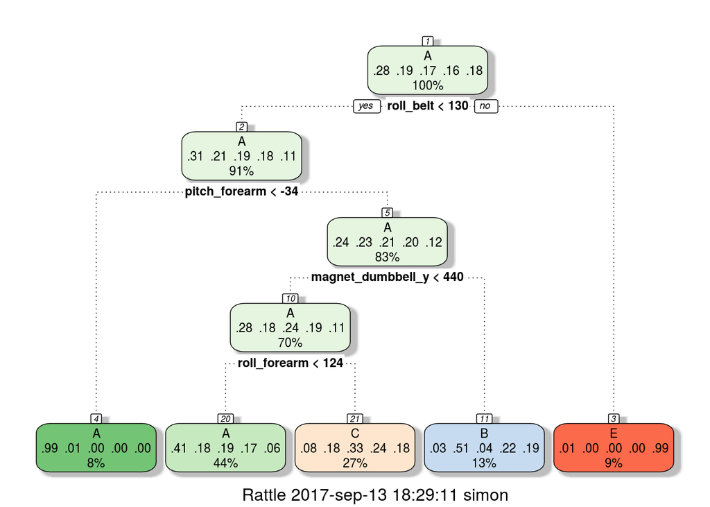

```r
fancyRpartPlot(classTrees$finalModel)
```

We can also take a look at the predictions made by this model and the confusion matrix associated

```r
classTreesPred <- predict(classTrees, valid)
cmtree <- confusionMatrix(classTreesPred, valid$classe)

# The accuracy of this model is the following
cmtree$overall['Accuracy']
```

```
##  Accuracy
## 0.5057219
```

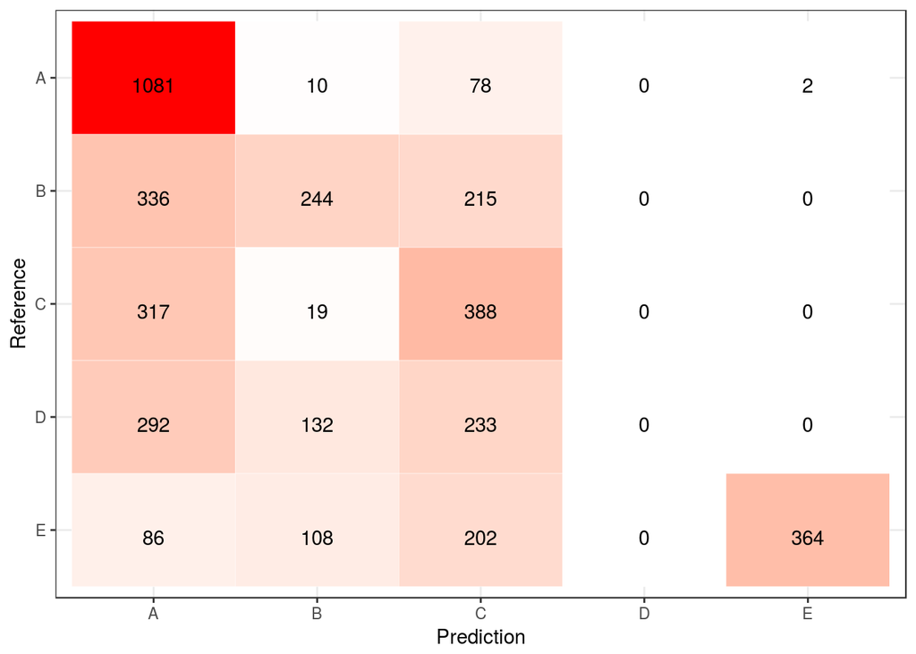

```r
# We can also plot the confusion matrix as a heatmap
clasTreesConfusion <- as.data.frame(cmtree$table)
clasTreesConfusion$Reference = with(clasTreesConfusion, factor(Reference, levels = rev(levels(Reference))))

ggplot(data =  clasTreesConfusion, mapping = aes(x = Prediction, y = Reference)) +
  geom_tile(aes(fill = Freq), colour = "white") +
  geom_text(aes(label = sprintf("%1.0f", Freq)), vjust = 1) +
  scale_fill_gradient(low = "white", high = "red") +
  theme_bw() + theme(legend.position = "none") +
  guides(fill = guide_colorbar(barwidth = 7, barheight = 1,
                title.position = "top", title.hjust = 0.5))
```

#### Predictions on the test set

Taking into account the accuracy of this method, the predictions produced for the test set are:

```r
finalClassPred <- predict(classTrees, test)       # Test set predictions
finalClassPred
```

```
##  [1] C A C A A C C A A A C C C A C A A A A C
## Levels: A B C D E
```

### Random Forest

We perform the same process as in classification trees but for Random Forests

```r
RF <- randomForest(classe ~ ., data=train)
RF                  # See explicitly the Random Forest results
```

```
##
## Call:
##  randomForest(formula = classe ~ ., data = train)
##                Type of random forest: classification
##                      Number of trees: 500
## No. of variables tried at each split: 7
##
##         OOB estimate of  error rate: 0.53%
## Confusion matrix:
##      A    B    C    D    E  class.error
## A 3903    2    0    0    1 0.0007680492
## B   16 2637    5    0    0 0.0079006772
## C    0   13 2379    4    0 0.0070951586
## D    0    0   21 2230    1 0.0097690941
## E    0    0    2    8 2515 0.0039603960
```

```r
predRF<- predict(RF, valid)
cmRF <- confusionMatrix(predRF, valid$classe)

# Accuracy of the RF
cmRF$overall['Accuracy']
```

```
## Accuracy
##        1
```

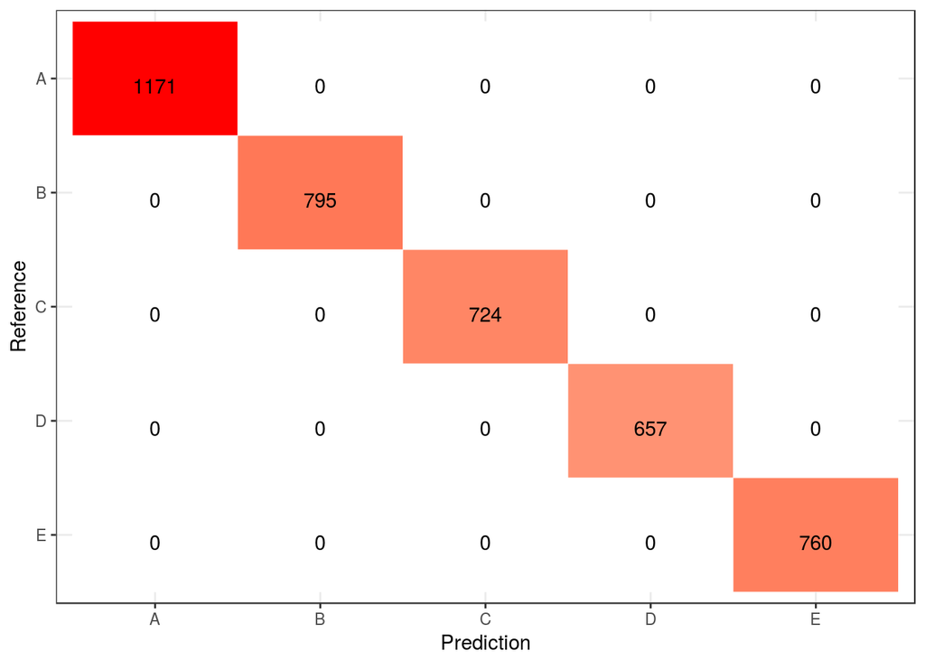

```r
# Plot the confusion matrix as a heatmap
confRF <- as.data.frame(cmRF$table)
confRF$Reference = with(confRF, factor(Reference, levels = rev(levels(Reference))))

ggplot(data =  confRF, mapping = aes(x = Prediction, y = Reference)) +
  geom_tile(aes(fill = Freq), colour = "white") +
  geom_text(aes(label = sprintf("%1.0f", Freq)), vjust = 1) +
  scale_fill_gradient(low = "white", high = "red") +
  theme_bw() + theme(legend.position = "none") +
  guides(fill = guide_colorbar(barwidth = 7, barheight = 1,
                title.position = "top", title.hjust = 0.5))
```

The accuracy for RF is far better than the one obtained for the Classification Trees, as expected. However, it is much more difficult to fit and to interpret.

#### Predictions on the test set

The predictions using Random Forest in the test set are the following:

```r
finalRFpred <- predict(RF, test)       # Test set predictions
finalRFpred
```

```
##  1  2  3  4  5  6  7  8  9 10 11 12 13 14 15 16 17 18 19 20
##  B  A  B  A  A  E  D  B  A  A  B  C  B  A  E  E  A  B  B  B
## Levels: A B C D E
```

This concludes the final project for the course.